# Two Sample t Test

Home | Examples

## Problem

Example Adapted from: https://onlinecourses.science.psu.edu/stat500/node/50

```r
new = c(42.1, 41.3, 42.4, 43.2, 41.8, 41.0, 41.8, 42.8, 42.3, 42.7) # Create a vector of samples
new # Display the vector to the console
```

```
##  [1] 42.1 41.3 42.4 43.2 41.8 41.0 41.8 42.8 42.3 42.7
```

```r
old = c(42.7, 43.8, 42.5, 43.1, 44.0, 43.6, 43.3, 43.5, 41.7, 44.1)
old
```

```
##  [1] 42.7 43.8 42.5 43.1 44.0 43.6 43.3 43.5 41.7 44.1
```

```r
n1 = length(new)
n2 = length(old)
```

## Sample Mean

New Sample Mean: $\bar{x}_1 = \frac{1}{n_1} \sum_{i=1}^{n_1} X_{i-new}$

Old Sample Mean: $\bar{x}_2 = \frac{1}{n_2} \sum_{i=1}^{n_2} X_{i-old}$

```r
newSampleMean = sum(new)/n1 # Using the equation for sample mean
newSampleMean
```

```
## [1] 42.14
```

```r
newSampleMean <- mean(new) # Easier to just use the R function
newSampleMean
```

```
## [1] 42.14
```

```r
oldSampleMean = mean(old)
oldSampleMean
```

```
## [1] 43.23
```

$\bar{x}_1 = 42.14$ and $\bar{x}_2 = 43.23$

## Sample Variance and Standard Deviation

$\sigma_1^2 = \frac{1}{n_1 - 1} \sum_{i=1}^{n_1} (\bar{x}_1 - X_{i-new})$

$\sigma_2^2 = \frac{1}{n_2 - 1} \sum_{i=1}^{n_2} (\bar{x}_2 - X_{i-old})$

```r
newSampleVariance = sum( (newSampleMean - new) ^ 2 )/(n1 - 1) # Using Formula
newSampleVariance
```

```
## [1] 0.4671111
```

```r
newSampleVariance <- var(new) # Using R function
newSampleVariance
```

```
## [1] 0.4671111
```

```r
newStandardDeviation = sqrt(newSampleVariance)
newStandardDeviation
```

```
## [1] 0.6834553
```

```r
oldSampleVariance = var(old)
oldSampleVariance
```

```
## [1] 0.5623333
```

```r
oldStandardDeviation = sqrt(oldSampleVariance)
oldStandardDeviation
```

```
## [1] 0.7498889
```

New Sample Variance: $\sigma_1^2 = 0.4671111$

New Standard Deviation: $\sigma_1 = 0.6834553$

Old Sample Variance: $\sigma_2^2 = 0.5623333$

Old Standard Deviation: $\sigma_2 = 0.7498889$

## Verify Normality

In order to be able to use the Two Sample t Test we need to verify that both samples follow a normal distribution.

The following graphs show how closely the points line up on the actual normal distribution, they should fit as closely as possible.

The dotted lines represent the bounds for a 95% confidence interval. As we can see none of the points fall outside the 95% CI, meaning we can be confident that `old` and `new` come from a normal population.

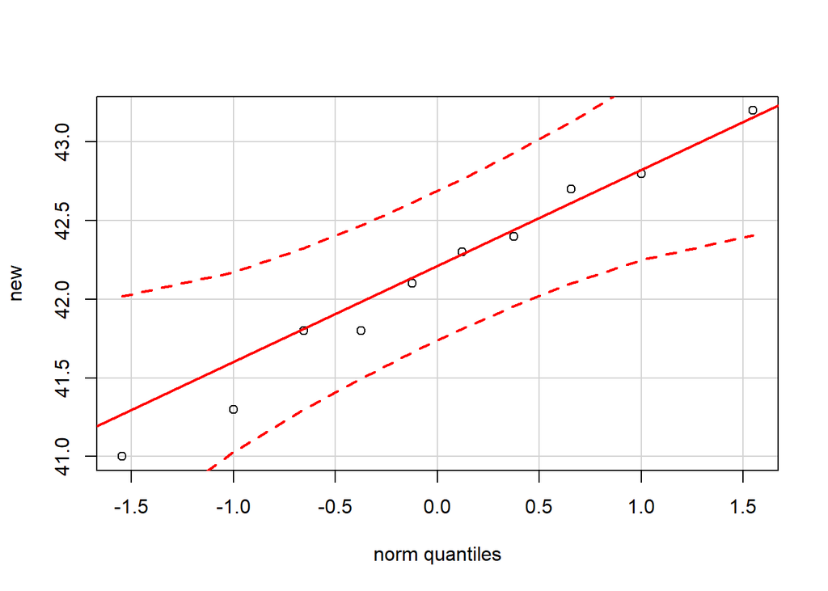

```r
library(car) # Importing the car library which includes qqPlot
qqPlot(new)
```

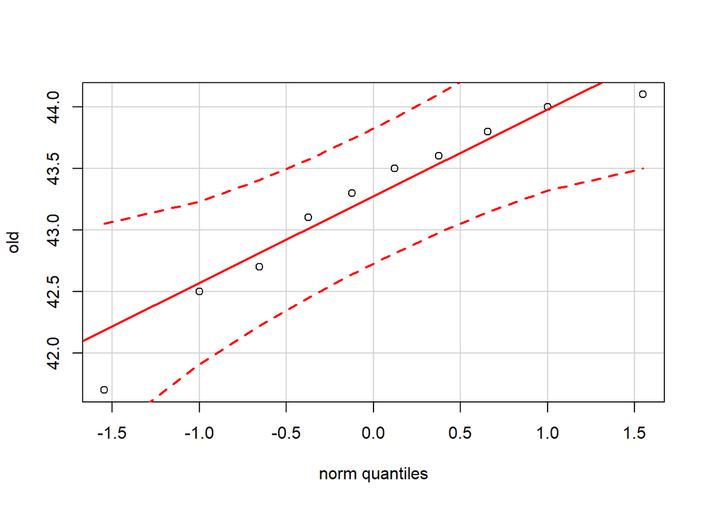

```r
qqPlot(old)
```

## Comparing Variance

In order to use the pooled t-test we must make sure the variance of the two samples is not too different.

```r
newStandardDeviation/oldStandardDeviation
```

```
## [1] 0.9114087
```

The standard deviation ratio is within 0.5 and 2, therefore we can perform the pooled t-test

## Pooled t-test

### Hypothesis

Let $\mu_1$ be the mean of `new` and $\mu_2$ be the mean of `old`

Then the hypotheses are:

$H_0 : \mu_1 - \mu_2 = 0,$

$H_a : \mu_1 - \mu_2 < 0$

### Significance Level

$\alpha = 0.05$

```r
alpha = 0.05
```

### Compute the t-statistic

Estimate the common standard deviation using the pooled standard deviation:

$$s_p = \sqrt{\frac{(n_1 - 1)s_1^2 + (n_2 - 1)s_2^2}{n_1 + n_2 - 2}}$$

Test Statistic:

$$t^* = \frac{\bar{x_1} - \bar{x_2}}{s_p\sqrt{\frac{1}{n_1} + \frac{1}{n_2}}}$$

with degrees of freedom $df = n_1 + n_2 - 2$

Plug in the variables:

```r
sp = sqrt(((n1 - 1) * newSampleVariance + (n2 - 1) * oldSampleVariance)/(n1 + n2 - 2))
sp
```

```
## [1] 0.7174414
```

$sp = 0.7174414$

$$t^* = \frac{42.14 - 43.23}{(0.7174414)\sqrt{\frac{1}{10} + \frac{1}{10}}}$$

```r
tStatistic = (newSampleMean - oldSampleMean)/(sp * sqrt(1/n1 + 1/n2))
tStatistic
```

```
## [1] -3.397231
```

$t^* = -3.397231$

### Critical Value

Critical Value: $-t_{\alpha} = -t_{0.05}$

Degrees of Freedom = $df = n1 + n2 - 2 = 10 + 10 - 2 = 18$

```r
df = n1 + n2 - 2
criticalValue = qt(alpha, df)
criticalValue
```

```
## [1] -1.734064
```

### Check Test Statistic vs Rejection Region

$t^* = -3.397231 < -1.734064$

```r
tStatistic < criticalValue
```

```
## [1] TRUE
```

Therefore we reject $H_0$ at $\alpha = 0.05$